# Fancy Violin Plots

Dr. Emily Burchfield

# Objectives

- Get even more familiar with `ggplot2` by making a killer violin plot.

# Packages

Make sure the `tidyverse` suite of packages are installed on your machine and loaded in your `R` session. The `tidyverse` includes both the `dplyr` and `ggplot2` packages.

```r
library(tidyverse)
```

# Our data

We’ll work with the 500 cities data again this week. You can read more about the data (and play around with the full dataset!) [here.](https://chronicdata.cdc.gov/browse?category=500+Cities)

```r
health <- readRDS("./data/health.RDS")
glimpse(health)
```

```
## Observations: 500
## Variables: 10
## $ CityName         <fct> Abilene, Akron, Alameda, Albany, Albany, Albu...
## $ StateAbbr        <fct> TX, OH, CA, GA, NY, NM, VA, CA, TX, PA, TX, C...
## $ PopulationCount  <int> 117063, 199110, 73812, 77434, 97856, 545852, ...
## $ BingeDrinking    <dbl> 16.2, 14.8, 15.0, 10.9, 15.5, 14.5, 15.1, 12....
## $ Smoking          <dbl> 19.6, 26.8, 11.9, 23.7, 19.0, 18.8, 13.0, 12....
## $ MentalHealth     <dbl> 11.6, 15.3, 9.8, 16.2, 13.2, 11.6, 8.4, 10.1,...
## $ PhysicalActivity <dbl> 27.7, 31.0, 18.7, 33.1, 26.1, 20.4, 17.6, 24....
## $ Obesity          <dbl> 33.7, 37.3, 18.7, 40.4, 31.1, 25.5, 23.3, 18....
## $ PoorHealth       <dbl> 12.6, 15.5, 9.6, 17.4, 13.1, 12.1, 8.4, 11.4,...
## $ LowSleep         <dbl> 35.4, 44.1, 32.3, 46.9, 39.7, 32.8, 34.5, 38....
```

Here’s some additional information about each of the variables in the dataset:

- `CityName` is the name of each of the 500 cities. Note that some names repeat (e.g. Albany, NY and Albany, GA)
- `StateAbbr` is the abbreviation for the state in which the city is located, including Washington D.C.
- `PopulationCount` is the total population in 2014 for each city.
- `BingeDrinking` is the rate of binge drinking among adults aged >= 18 years.
- `Smoking` is the rate of current smoking among adults aged >= 18 years.
- `MentalHealth` is the rate of low mental health for more than 14 days among adults aged >= 18 years.
- `PhysicalActivity` is the rate of low physical activity among adults aged >= 18 years.
- `Obesity` is the rate of obesity among adults aged >= 18 years.
- `PoorHealth` is the rate of low physical health for more than 14 days among adults aged >= 18 years.
- `LowSleep` is the rate of sleeping less than 7 hours among adults aged >= 18 years.

# One classy violin plot

This week, we’ll continue working on becoming professional-ggplotters by creating a really awesome violin plot. Violin plots are like box-and-whisker plots in that they let us quickly visually compare a single variable across groups. They are even cooler than box-and-whisker plots (I know, I know, how is it POSSIBLE to be cooler than our friends B&W!?) because not only do they show the center and spread of a variable, they also show us the *shape* of the distributions.

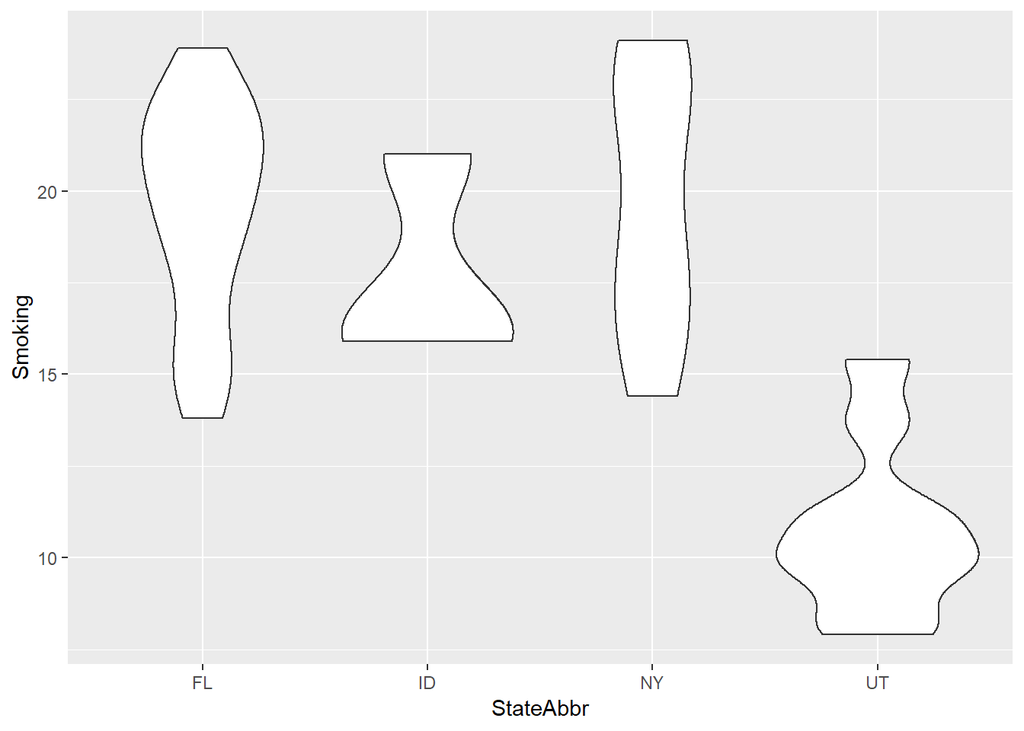

```r
p <- health %>%
  filter(StateAbbr %in% c("UT", "FL", "NY", "ID")) %>%
  ggplot() +
  geom_violin(aes(x = StateAbbr, y = Smoking))
p
```

This plot shows us a bit more information that a box-and-whisker plot, since it also gives us a sense of the *shape* of city-level distributions in each state in our dataset. We’re missing, however, visual cues about the median and spread (quartiles) of each state’s smoking rates provided by default in our box-and-whisker plots. Let’s add those and update our plot object `p`:

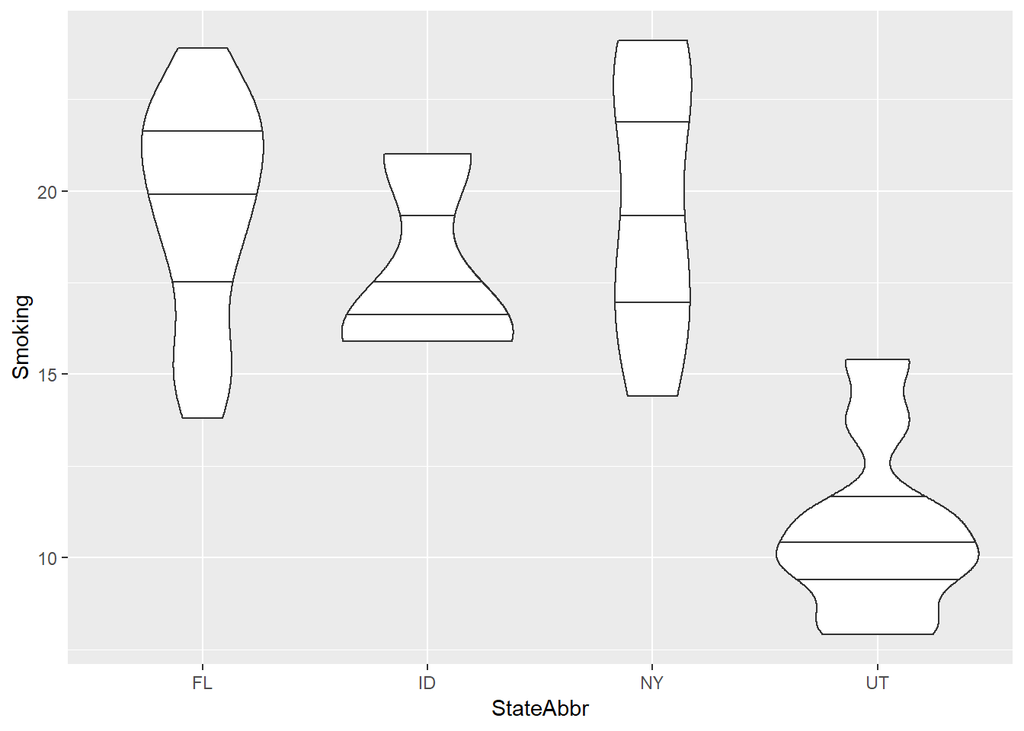

```r
p + geom_violin(aes(x = StateAbbr, y = Smoking), draw_quantiles = c(0.25, 0.5, 0.75))
```

Nice! Another way to do this is:

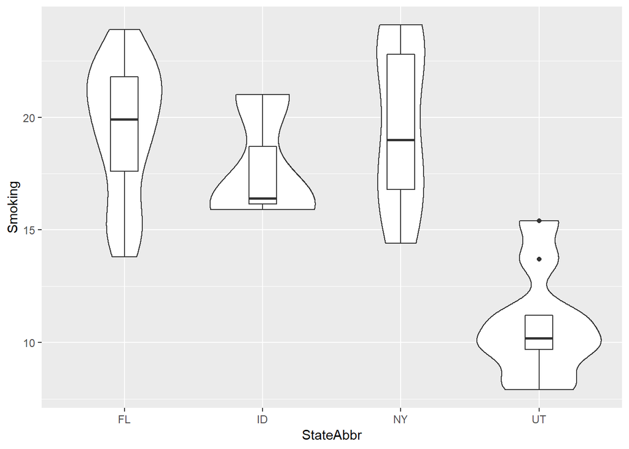

```r
p + geom_boxplot(aes(x = StateAbbr, y = Smoking), width = 0.2)
```

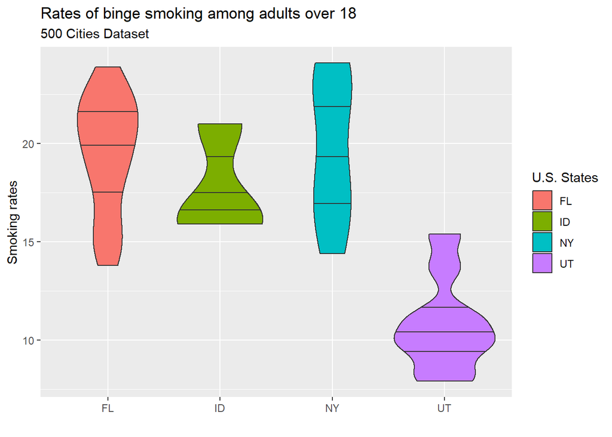

```r
p2 <- p +
  geom_violin(aes(x = reorder(StateAbbr, desc(Smoking)), y = Smoking, fill = StateAbbr), draw_quantiles = c(0.25, 0.5, 0.75)) +
  guides(fill=guide_legend(title="U.S. States")) +
  xlab("") +
  ylab("Smoking rates") +
  labs(title = "Rates of binge smoking among adults over 18", subtitle = "500 Cities Dataset")
p2
```

This looks OK, but I’d like to remove the gray background:

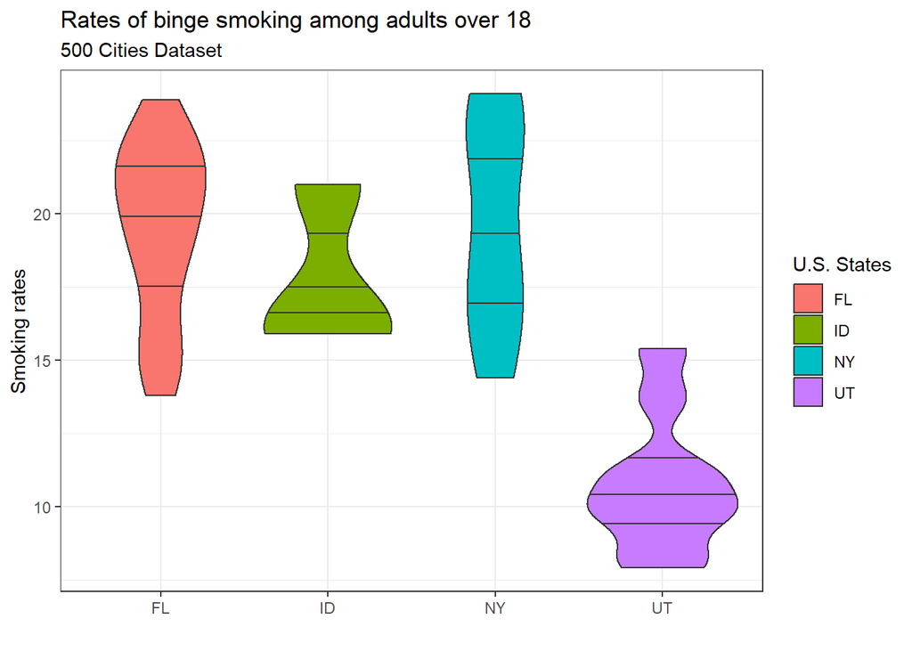

```r
p3 <- p2 + theme_bw()
p3
```

Finally, I’d like to drop the legend on the bottom:

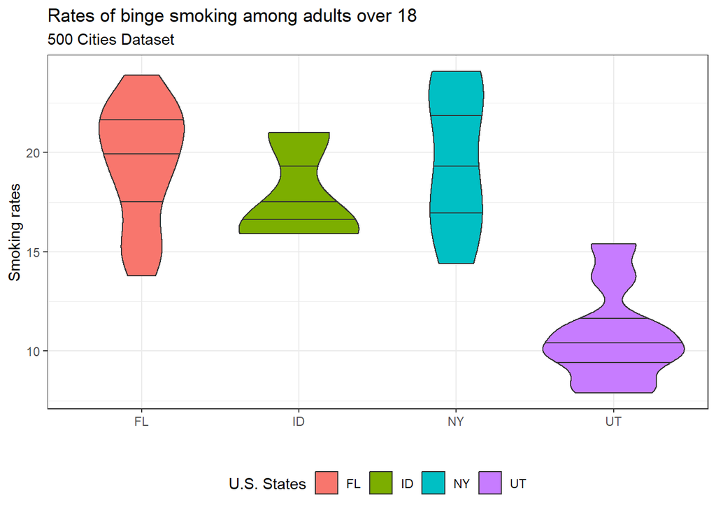

```r
p4 <- p3 + theme(legend.position = "bottom")
p4
```

Here’s all the code needed to reproduce this figure:

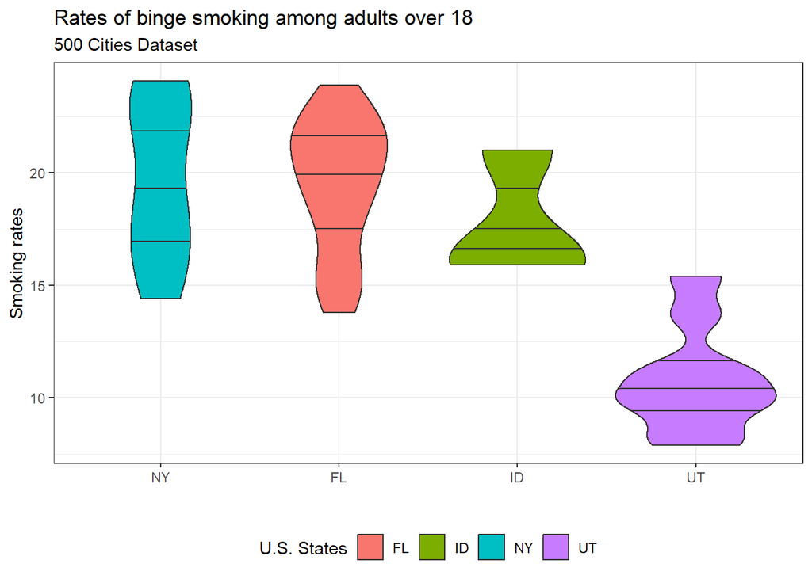

```r
final_violin <- health %>%
  filter(StateAbbr %in% c("UT", "FL", "NY", "ID")) %>%
  ggplot() +
  geom_violin(aes(x = reorder(StateAbbr, desc(Smoking)), y = Smoking, fill = StateAbbr), draw_quantiles = c(0.25, 0.5, 0.75)) +
  guides(fill=guide_legend(title="U.S. States")) +
  xlab("") +
  ylab("Smoking rates") +
  labs(title = "Rates of binge smoking among adults over 18", subtitle = "500 Cities Dataset") +
  theme_bw() +
  theme(legend.position = "bottom")

final_violin
```

Now wouldn’t it ALSO be really really cool to add the actual data points to this plot?? Let’s do it!

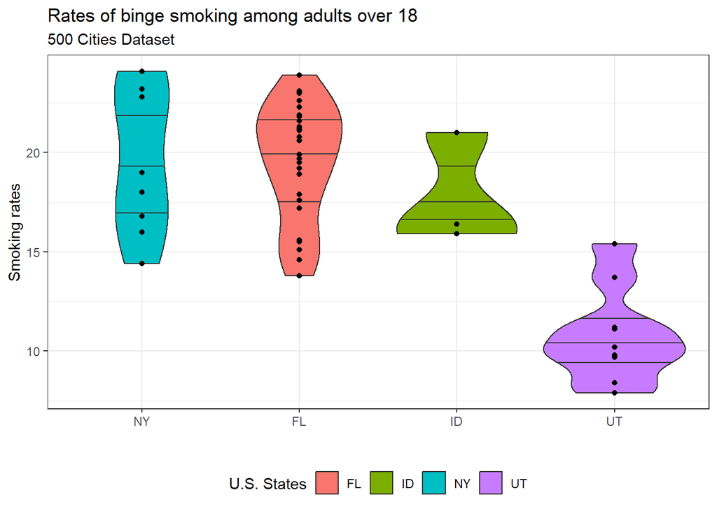

```r
final_violin +
  geom_point(aes(x = reorder(StateAbbr, desc(Smoking)), y = Smoking))
```

In Florida, there are so many cities, it’s a bit hard to distinguish between points. Let’s “jitter” the points to facilitate visualization. This is a tool that adds random noise to our data to facilitate visualization (to prevent over-plotting). In this case, it moves the data points to the left and right so we can better see distinct cities.

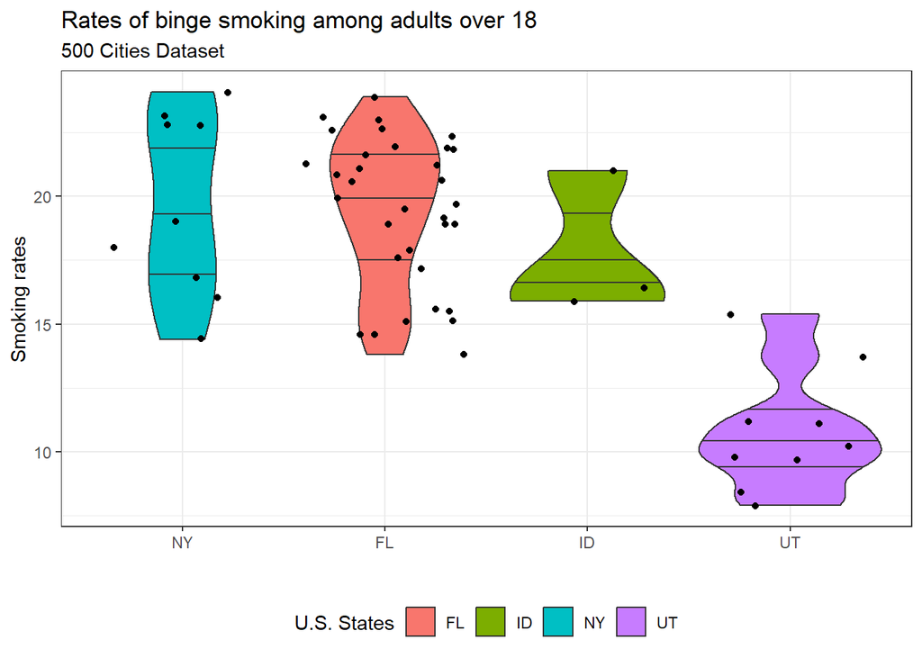

```r
final_violin +
  geom_jitter(aes(x = reorder(StateAbbr, desc(Smoking)), y = Smoking))
```

That’s a bit too much jitter. We can reduce the width of the jitter like so:

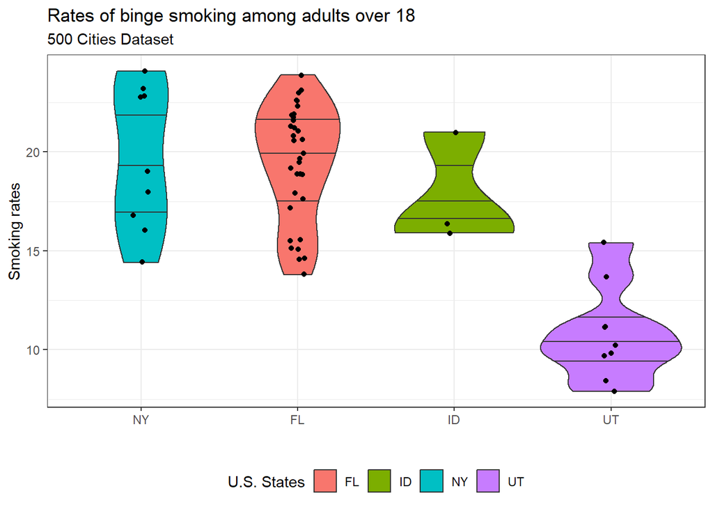

```r
final_violin +
  geom_jitter(aes(x = reorder(StateAbbr, desc(Smoking)), y = Smoking), width=0.05)
```

# Saving your figures

When working with `ggplot2`, save figures using the `ggsave()` function. Note that to use this function, you’ll need to dump your ggplot into a variable:

```r
my_sweet_plot <- ggplot(data = my_data) +
  geom_point(aes(x = YEAR, y = VALUE))

ggsave(my_sweet_plot, "./myfigure.png")
```

You can read more about writing your figures to a other types of files [here](http://stat545.com/block017_write-figure-to-file.html).

# Additional Resources

- More on creative ways to visualize data distributions [here](https://rafalab.github.io/dsbook/distributions.html)
- [Secrets of a happy graphing life](http://stat545.com/block016_secrets-happy-graphing.html)
- The [ggplot2 cheatsheet](https://www.rstudio.com/wp-content/uploads/2015/03/ggplot2-cheatsheet.pdf)
- Chapters 5 - 12 in this [online textbook](https://serialmentor.com/dataviz/visualizing-amounts.html) provide a great overview of when to use different visualization strategies.